# Tutorial - Utilizando a Biblioteca MicrodataSUS para aquisição de Microdados de Sistemas de Informação em Saúde (SIS)

Davi Alves

29/04/2021

# Instalando o pacote *“microdatasus”*

A seguir serão apresentados de maneira resumida os procedimentos para instalação do pacote **microdatasus**. O detalhamento destes procedimentos estão dealhandos neste [link](https://github.com/rfsaldanha/microdatasus) e neste [artigo](http://ref.scielo.org/dhcq3y).

Inicialmente é necessário instalar o pacote **devtools** e carregá-lo utlizando os comandos a seguir:

```r
# Instalando o pacote:
install.packages("devtools")
```

```r
# Carregando o pacote:
require("devtools")
```

O procdimento também pode ser realizado através dos menus do R através da guia *Pacotes* e em seguida *Instalar Pacote(s)…*:

[figure not shown]

Selecione o pacote **devtools** e clique em **OK**:

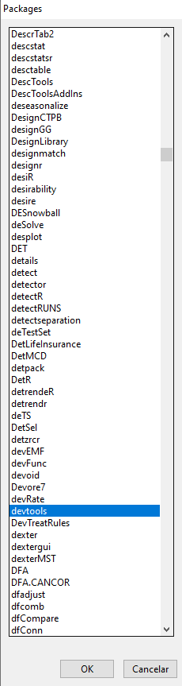

Após a instalação e o carregamento do pacote **devtools**, instale o pacote **microdatasus** utilizando o seguinte comando:

```r
install_github("rfsaldanha/microdatasus")
```

Em seguida, carregue o pacote *microdatasus*:

```r
library(microdatasus)
```

# Acessando microdados com a biblioteca *microdatasus*

O pacote **microdatasus** permite a aquisição e processamento de microdados de diversos Sistemas de Informação em Saúde (SIS). Os SIS que podem ser acessados utilizando este pacote estão detalhados no [artigo](http://ref.scielo.org/dhcq3y). Neste tutorial, serão apresentados os procedimentos para acessar microdados do Sistema de Informação sobre Mortalidade - SIM, Sistema de Informação sobre Nascidos Vicos - SINASC e o Sistema de Informações Hospitalares - SIH.

## O comando básico para acessar os microdados: *fetch_datasus()*

A função *fetch_datasus()* do pacote **microdatasus** é utilizado para acessar os dados dos diferentes SIS. Os seus principais argmentos são:

- *year_start*: Indica o ano do início do período dos dados que serão adquiridos. Deve ser indicado como um número de quatro dígitos.
- *year_end*: Indica o ano de término do período. Deve ser indicado como um número de quatro dígitos e para adquirir dados de um único ano, os argumentos *year_start* e *yer_end* devem ser iguais.
- *uf*: Indica a(s) UF(s) para a quais se deseja as informações. As UF(s) devem ser indicadas através de sua sigla em maiúsculo e entre aspas, como por exemplo *“RJ”* para o Rio de Janeiro. Para adquirir dados referentes a todo o Brasil deve-se utilizar a opção *“all”* e para adquirir dados de mais de uma UF é necessário concatenar as siglas. Para acessar dados de Minas Gerais e Espírito Santo, por exemplo, deve-se indica *uf=c(“MG”,“ES”)*.
- *month_start*: Indica o mês do início do período dos dados que serão adquiridos. Deve ser indicado como um número de dois dígitos entre 0 e 12. Não é aplicado a todos os SIS.
- *month_end*: Indica o mês do fim do período dos dados que serão adquiridos. Deve ser indicado como um número de dois dígitos entre 0 e 12. Não é aplicado a todos os SIS.
- *information_system*: Indica o sistema de informação do qual se deseja obter os dados. As siglas referentes a cada um dos sistemas estão disponíveis no [artigo](http://ref.scielo.org/dhcq3y), e devem ser indicadas sempre em maíusculo e entre aspas.

Desta maneira, o comando padrão para aquisição dos microdados: é **nome_banco <- fetch_datasus(year_start=ano, year_end=ano, uf=“UF”, information_system=“SIGLA_SISTEMA”)**

## Os comandos para processar os microdados: *process_sim()*, *process_sih()* e *process_sinasc()*

Nos bancos de dados dos microdados dos SIS as variáveis categóricas são representadas por códigos (números). No Sistema de Informação sobre Mortalidade - SIM - por exemplo, o sexo é registrado como **1** para o sexo **Masculino** e **2** para o sexo **Feminino**. O DataSUS oferece toda a documentação e arquivos necessários para o processamento destas informações de maneira correta. Geralmente este é um procedimento que demanda tempo e domínio de programação em R e ambém do próprio SIS.

Contudo, o pacote **microdatasus** permite o processamento destas informações, substituindo os códigos pela legenda de cada categoria das variáveis disponíveis. As funções para o processamento do banco de dados são específicas para os dados de cada sistema e neste tutorial serão apresentados 3 comandos principais de de processamento de dados baixados:

- **nome_banco_processado <- process_sim(nome_banco_sim)**
- **nome_banco_processado <- process_sih(nome_banco_sih)**
- **nome_banco_processado <- process_sinasc(nome_banco_sinasc)**

A função **process_sim** é uilizada para processar dados acerca da mortalidade oriundos do Sistema de Informação sorbe a Mortalidade (SIM) enquanto a função **process_sih** é utilizada para processar os dados referentes às internações hospitalares do Sistema de Informações Hospitalares (SIH) e a função **process_sinasc** permite processar os dados sobre nascimentos do Sistema de Infromação Sobre Nascidos Vivos (SINASC).

## Acessando e processando dados sobre os Nascimentos

Neste exemplo, iremos acessar microdados sobre os nascimentos no estado do Rio de Janeiro em 2019, ano mais recente com informações disponínveis, alocando estes dados em banco com o nome *nv_rj_19*.

Para baixar o banco de dados devemos utilizar o comando:

```r
nv_rj_19 <- fetch_datasus(year_start=2019, year_end=2019, uf="RJ", information_system="SINASC")
```

Este banco, *nv_rj_19*, contém as informações brutas referentes aos nascmentos do estado no ano selecionado:

|  | ORIGEM | CODESTAB | CODMUNNASC | LOCNASC | IDADEMAE | ESTCIVMAE | ESCMAE | CODOCUPMAE | QTDFILVIVO | QTDFILMORT | CODMUNRES | GESTACAO | GRAVIDEZ | PARTO | CONSULTAS |
| --- | --- | --- | --- | --- | --- | --- | --- | --- | --- | --- | --- | --- | --- | --- | --- |
| 1 | 1 | 2365146 | 220390 | 1 | 26 | 1 | 3 |  | 01 | 02 | 330455 | 5 | 1 | 1 | 4 |
| 2 | 1 | 2727064 | 221100 | 1 | 29 | 5 | 4 | 521110 | 00 | 00 | 330455 | 4 | 1 | 1 | 4 |
| 3 | 1 | 2561344 | 230500 | 1 | 27 | 5 | 3 | 999993 | 04 | 00 | 330455 | 5 | 1 | 1 | 4 |
| 4 | 1 | 2473577 | 240710 | 1 | 18 | 5 | 4 | 622020 |  |  | 330455 | 5 | 1 | 2 | 4 |
| 5 | 1 | 2654032 | 240810 | 1 | 30 | 2 | 4 | 351305 | 00 | 00 | 330490 | 5 | 1 | 2 | 4 |
| 6 | 1 | 2707527 | 250750 | 1 | 25 | 2 | 3 | 521110 | 00 | 00 | 330455 | 5 | 1 | 1 | 4 |
| 7 | 1 | 2336812 | 250970 | 1 | 32 | 5 | 4 | 999992 | 02 | 00 | 330455 | 5 | 1 | 1 | 3 |
| 8 | 1 | 2757710 | 251140 | 1 | 20 | 5 | 4 | 622020 | 01 | 00 | 330455 | 5 | 1 | 1 | 4 |
| 9 | 1 | 2703041 | 260280 | 1 | 32 | 2 | 4 |  | 03 | 00 | 330350 | 4 | 1 | 1 | 3 |
| 10 | 1 | 2344882 | 260960 | 1 | 26 | 1 | 4 | 516110 | 01 | 02 | 330455 | 5 | 1 | 1 | 3 |

[output cut: 90 more lines]

Para processar as informações em um banco de dados nomeado *nv_rj_19_proc*, o comando a ser utilizado é:

```r
nv_rj_19_proc <- process_sinasc(nv_rj_19)
```

Após utilizar este comando o banco de dados *nv_rj_19_proc* apresentará as informações devidamente processadas:

|  | ORIGEM | CODESTAB | CODMUNNASC | LOCNASC | IDADEMAE | ESTCIVMAE | ESCMAE | CODOCUPMAE | QTDFILVIVO | QTDFILMORT | CODMUNRES | GESTACAO | GRAVIDEZ | PARTO | CONSULTAS |
| --- | --- | --- | --- | --- | --- | --- | --- | --- | --- | --- | --- | --- | --- | --- | --- |
| 1 | 1 | 2365146 | 220390 | Hospital | 26 | Solteira | 4 a 7 anos |  | 1 | 2 | 330455 | 37 a 41 semanas | Única | Vaginal | 7 ou mais vezes |
| 2 | 1 | 2727064 | 221100 | Hospital | 29 | União consensual | 8 a 11 anos | Vendedor de comércio varejista | 0 | 0 | 330455 | 32 a 36 semanas | Única | Vaginal | 7 ou mais vezes |
| 3 | 1 | 2561344 | 230500 | Hospital | 27 | União consensual | 4 a 7 anos | Aposentado/Pensionista | 4 | 0 | 330455 | 37 a 41 semanas | Única | Vaginal | 7 ou mais vezes |
| 4 | 1 | 2473577 | 240710 | Hospital | 18 | União consensual | 8 a 11 anos | Trabalhador volante da agricultura |  |  | 330455 | 37 a 41 semanas | Única | Cesáreo | 7 ou mais vezes |
| 5 | 1 | 2654032 | 240810 | Hospital | 30 | Casada | 8 a 11 anos | Técnico em administração | 0 | 0 | 330490 | 37 a 41 semanas | Única | Cesáreo | 7 ou mais vezes |
| 6 | 1 | 2707527 | 250750 | Hospital | 25 | Casada | 4 a 7 anos | Vendedor de comércio varejista | 0 | 0 | 330455 | 37 a 41 semanas | Única | Vaginal | 7 ou mais vezes |
| 7 | 1 | 2336812 | 250970 | Hospital | 32 | União consensual | 8 a 11 anos | Dona de Casa | 2 | 0 | 330455 | 37 a 41 semanas | Única | Vaginal | 4 a 6 vezes |
| 8 | 1 | 2757710 | 251140 | Hospital | 20 | União consensual | 8 a 11 anos | Trabalhador volante da agricultura | 1 | 0 | 330455 | 37 a 41 semanas | Única | Vaginal | 7 ou mais vezes |
| 9 | 1 | 2703041 | 260280 | Hospital | 32 | Casada | 8 a 11 anos |  | 3 | 0 | 330350 | 32 a 36 semanas | Única | Vaginal | 4 a 6 vezes |
| 10 | 1 | 2344882 | 260960 | Hospital | 26 | Solteira | 8 a 11 anos | Cabeleireiro | 1 | 2 | 330455 | 37 a 41 semanas | Única | Vaginal | 4 a 6 vezes |

[output cut: 90 more lines]

## Acessando e processando dados sobre Óbtios

Neste exemplo, iremos acessar microdados sobre os óbitos registrados no estado do Espírito Santo em 2019, ano mais recente com informações disponínveis, alocando estes dados em banco com o nome *obt_es_19*.

Para baixar o banco de dados devemos utilizar o comando:

```r
obt_es_19 <- fetch_datasus(year_start=2019, year_end=2019, uf="ES", information_system="SIM-DO")
```

Este banco, *obt_es_19*, contém as informações brutas referentes aos óbitos do estado no ano selecionado:

[output not shown]

[output cut: 90 more lines]

Para processar as informações em um banco de dados nomeado *obt_es_19_proc*, o comando a ser utilizado é:

```r
obt_es_19_proc <- process_sim(obt_es_19)
```

Após utilizar este comando o banco de dados *obt_es_19_proc* apresentará as informações devidamente processadas:

|  | ORIGEM | TIPOBITO | DTOBITO | HORAOBITO | NATURAL | CODMUNNATU | DTNASC | SEXO | RACACOR | ESTCIV | ESC | ESC2010 | SERIESCFAL | OCUP | CODMUNRES |
| --- | --- | --- | --- | --- | --- | --- | --- | --- | --- | --- | --- | --- | --- | --- | --- |
| 1 | 1 | Não Fetal | 2019-01-02 |  | Bahia | 291080 | 2000-06-26 | Masculino | Parda | Solteiro | 1 a 3 anos | 1 |  | Representante comercial autônomo | 320530 |
| 2 | 1 | Não Fetal | 2019-01-11 | 1400 |  |  | 1937-02-11 | Masculino | Parda | Viúvo | Nenhuma | 0 |  | Pedreiro | 320530 |
| 3 | 1 | Não Fetal | 2019-01-13 | 0845 | Espírito Santo | 320530 | 1952-09-17 | Masculino | Branca | Casado | 8 a 11 anos | 3 |  | Aposentado/Pensionista | 320530 |
| 4 | 1 | Não Fetal | 2019-01-14 | 0535 |  |  | 1932-01-22 | Feminino | Branca | Viúvo | 12 anos ou mais | 5 |  | Pedagogo | 320530 |
| 5 | 1 | Não Fetal | 2019-01-15 | 0700 | Espírito Santo | 320130 | 1937-07-17 | Feminino | Parda | Viúvo |  | 9 |  | Costureira de peças sob encomenda | 320530 |
| 6 | 1 | Não Fetal | 2019-01-16 |  | Espírito Santo | 320530 | 1984-03-22 | Masculino | Parda | Solteiro | 8 a 11 anos | 3 | 3 | Vendedor de comércio varejista | 320530 |
| 7 | 1 | Não Fetal | 2019-01-14 |  | Espírito Santo | 320530 | 1992-09-05 | Masculino | Parda | Solteiro |  | 9 |  | Pedreiro | 320520 |
| 8 | 1 | Não Fetal | 2019-01-16 | 1715 | Minas Gerais | 310110 | 1960-07-28 | Masculino | Branca | Separado judicialmente |  | 9 |  | Serralheiro | 320520 |
| 9 | 1 | Não Fetal | 2019-01-17 | 2334 | Espírito Santo | 320450 | 1932-03-12 | Feminino | Branca |  | 4 a 7 anos | 1 | 4 | Dona de Casa | 320530 |
| 10 | 1 | Não Fetal | 2019-01-24 | 0104 | Espírito Santo | 320000 | 1930-06-24 | Feminino |  | Solteiro | 1 a 3 anos | 1 |  |  | 320460 |

[output cut: 90 more lines]

## Acessando e processando dados sobre as Internações

Neste exemplo, iremos acessar microdados sobre as internações registradas no estado do Acre de janeiro a dezembro de 2020 no âmbito do SUS, alocando estes dados em banco com o nome *int_ac_20*.

Para baixar o banco de dados devemos utilizar o comando:

```r
int_ac_20 <- fetch_datasus(year_start=2020, year_end=2020, month_start = 1,month_end = 12, uf="AC", information_system="SIH-RD")
```

Este banco, *int_ac_20*, contém as informações brutas referentes às internaões do estado registrados no âmbito do SUS no ano selecionado:

|  | UF_ZI | ANO_CMPT | MES_CMPT | ESPEC | CGC_HOSP | N_AIH | IDENT | CEP | MUNIC_RES | NASC | SEXO | UTI_MES_IN | UTI_MES_AN | UTI_MES_AL | UTI_MES_TO |
| --- | --- | --- | --- | --- | --- | --- | --- | --- | --- | --- | --- | --- | --- | --- | --- |
| 1 | 120000 | 2020 | 01 | 03 | 04034526000224 | 1220100002880 | 1 | 69920193 | 120040 | 19881019 | 1 | 0 | 0 | 0 | 0 |
| 2 | 120000 | 2020 | 01 | 03 | 04034526000224 | 1220100002891 | 1 | 69905440 | 120040 | 19530519 | 1 | 0 | 0 | 0 | 0 |
| 3 | 120000 | 2020 | 01 | 03 | 04034526000224 | 1220100004068 | 1 | 69902100 | 120040 | 20180719 | 1 | 0 | 0 | 0 | 0 |
| 4 | 120000 | 2020 | 01 | 07 | 04034526000224 | 1219100548732 | 1 | 69905292 | 120040 | 20181103 | 3 | 0 | 0 | 0 | 0 |
| 5 | 120000 | 2020 | 01 | 07 | 04034526000224 | 1219100548743 | 1 | 69900970 | 120040 | 20190110 | 3 | 0 | 0 | 0 | 0 |
| 6 | 120000 | 2020 | 01 | 07 | 04034526000224 | 1219100548754 | 1 | 69900970 | 120040 | 20190427 | 1 | 0 | 0 | 0 | 0 |
| 7 | 120000 | 2020 | 01 | 07 | 04034526000224 | 1219100548765 | 1 | 69940000 | 120050 | 20181125 | 1 | 0 | 0 | 0 | 0 |
| 8 | 120000 | 2020 | 01 | 07 | 04034526000224 | 1219100548776 | 1 | 69900970 | 120040 | 20190415 | 3 | 0 | 0 | 0 | 0 |
| 9 | 120000 | 2020 | 01 | 02 | 04034526000305 | 1219100517217 | 1 | 69911418 | 120040 | 19941123 | 3 | 0 | 0 | 0 | 0 |
| 10 | 120000 | 2020 | 01 | 02 | 04034526000305 | 1219100517437 | 1 | 69900970 | 120040 | 20040531 | 3 | 0 | 0 | 0 | 0 |

[output cut: 90 more lines]

Para processar as informações em um banco de dados nomeado *int_ac_20_proc*, o comando a ser utilizado é:

```r
int_ac_20_proc <- process_sih(int_ac_20)
```

Após utilizar este comando o banco de dados *int_ac_20_proc* apresentará as informações devidamente processadas:

|  | UF_ZI | ANO_CMPT | MES_CMPT | ESPEC | CGC_HOSP | N_AIH | IDENT | CEP | MUNIC_RES | NASC | SEXO | UTI_MES_IN | UTI_MES_AN | UTI_MES_AL | UTI_MES_TO |
| --- | --- | --- | --- | --- | --- | --- | --- | --- | --- | --- | --- | --- | --- | --- | --- |
| 1 | 120000 | 1 | 1 | Clínica médica | 04034526000224 | 1220100002880 | Principal | 69920193 | 120040 | 1988-10-19 | Masculino | 0 | 0 | 0 | 0 |
| 2 | 120000 | 1 | 1 | Clínica médica | 04034526000224 | 1220100002891 | Principal | 69905440 | 120040 | 1953-05-19 | Masculino | 0 | 0 | 0 | 0 |
| 3 | 120000 | 1 | 1 | Clínica médica | 04034526000224 | 1220100004068 | Principal | 69902100 | 120040 | 2018-07-19 | Masculino | 0 | 0 | 0 | 0 |
| 4 | 120000 | 1 | 1 | Pediatria | 04034526000224 | 1219100548732 | Principal | 69905292 | 120040 | 2018-11-03 | Feminino | 0 | 0 | 0 | 0 |
| 5 | 120000 | 1 | 1 | Pediatria | 04034526000224 | 1219100548743 | Principal | 69900970 | 120040 | 2019-01-10 | Feminino | 0 | 0 | 0 | 0 |
| 6 | 120000 | 1 | 1 | Pediatria | 04034526000224 | 1219100548754 | Principal | 69900970 | 120040 | 2019-04-27 | Masculino | 0 | 0 | 0 | 0 |
| 7 | 120000 | 1 | 1 | Pediatria | 04034526000224 | 1219100548765 | Principal | 69940000 | 120050 | 2018-11-25 | Masculino | 0 | 0 | 0 | 0 |
| 8 | 120000 | 1 | 1 | Pediatria | 04034526000224 | 1219100548776 | Principal | 69900970 | 120040 | 2019-04-15 | Feminino | 0 | 0 | 0 | 0 |
| 9 | 120000 | 1 | 1 | Obstetrícia | 04034526000305 | 1219100517217 | Principal | 69911418 | 120040 | 1994-11-23 | Feminino | 0 | 0 | 0 | 0 |
| 10 | 120000 | 1 | 1 | Obstetrícia | 04034526000305 | 1219100517437 | Principal | 69900970 | 120040 | 2004-05-31 | Feminino | 0 | 0 | 0 | 0 |

[output cut: 90 more lines]

# Salvando o banco de dados

Após realizar o download, processar as informações do banco de dados e realizar o devido preparo da base e das variáveis de interesse, o banco de dados pode ser salvo em forma *.RData*, próprio do R, de maneira que pode ser aberto para análises a qualquer momento. O procedimento está detalhado no tópico **3.1 Salvando conjuntos de dados** da página 15 da [apostila de R Commander](http://gae.uniriotec.br/7/Notas_de_aula_Rcmdr.pdf).

Inicialmente, clique para selecionar o conjunto de dados ativos:

[figure not shown]

Em seguida, selecione o conjunto de dados:

[figure not shown]

Com o banco de dados selecionado, selecione o menu *Dados*, em seguida, *Conjunto de Dados Ativo* e então *Salvar Conjunto de Dados Ativo*:

[figure not shown]

Na janela que se abrirá, selecione o diretório e a pasta em que deseja salvar a base,digite o nome do arquivo e clique em *salvar*:

[figure not shown]

Posteriormente, para carregar esta base de dados, siga os procedimentos apresentados no tópico **3.2 Carregando conjuntos de dados (no formato .RData)** da página 15 da [apostila de R Commander](http://gae.uniriotec.br/7/Notas_de_aula_Rcmdr.pdf).